# Actividad 3 - Modelización predictiva

Jorge Alonso Hernández

13 de December, 2021

```r
# Carga de librerías
if (!require('faraway')) install.packages('faraway'); library('faraway')
if (!require('car')) install.packages('car'); library('car')
```

```r
#Lectura de fichero
ruta_csv <- "C:\\Users\\Jorge\\Documents\\Rstudio Workspace\\Estadística Avanzada\\Actividad 3\\dat_Air.csv"
data_air <- read.csv(ruta_csv, na.strings="NA")

head(data_air)
```

```
##   Estacion  latitud  longitud     Fecha Periodo SO2  H2S NO NO2 NOX O3 PM10
## 1       12 43.52096 -5.690707 11/7/2021      24   1 18.3  5  36  43  5   95
## 2       12 43.52096 -5.690707 11/7/2021      23   1  6.2  2  22  24 10   80
## 3       12 43.52096 -5.690707 11/7/2021      22   1  4.3  1  19  20 14   38
## 4       12 43.52096 -5.690707 11/7/2021      21   1  2.7  4  21  26 11   36
## 5       12 43.52096 -5.690707 11/7/2021      20   1  2.1  2  18  20 16   30
## 6       12 43.52096 -5.690707 11/7/2021      19   1  1.3  1  10  10 24   21
##   PM25 BEN TOL MXIL Dir_Aire  Vel  Tmp HR  PRB RS LL
## 1   30 1.6 2.3  3.2      260 1.49 11.8 93 1025 36  0
## 2   23 0.7 1.8  2.7      201 0.98 11.6 93 1025 36  0
## 3   15 0.6 1.1  3.1      296 0.98 11.2 92 1025 37  0
## 4   12 0.9 1.3  2.2      185 0.99 11.9 88 1026 37  0
## 5   12 0.2 0.6  0.8      297 0.99 12.4 85 1026 37  0
## 6   17 0.3 0.6  1.0      295 0.99 12.4 83 1026 37  0
```

# 1 Regresión lineal

## 1.1 Estudio de correlación lineal

Para realizar el calculo de la matriz de correlación entre las variables contaminantes: O3, NO2 y PM10 y las variables meteorológicas Tmp, HR, RS,Vel y Dir_Air obtendremos dichas variables en dos dataframe separados.

```r
data_air_cont<- data_air[,c("O3", "NO2", "PM10")]
data_air_met <- data_air[,c("Tmp", "HR", "RS", "Vel", "Dir_Aire")]
```

Mostramos las cabeceras de ambos dataframes para corroborar que son las variables que queremos.

```r
head(data_air_cont)
```

```
##   O3 NO2 PM10
## 1  5  36   95
## 2 10  22   80
## 3 14  19   38
## 4 11  21   36
## 5 16  18   30
## 6 24  10   21
```

```r
head(data_air_met)
```

```
##    Tmp HR RS  Vel Dir_Aire
## 1 11.8 93 36 1.49      260
## 2 11.6 93 36 0.98      201
## 3 11.2 92 37 0.98      296
## 4 11.9 88 37 0.99      185
## 5 12.4 85 37 0.99      297
## 6 12.4 83 37 0.99      295
```

Empleamos la función cor() para obtener la matriz de correlación entre las variables contaminantes y las variables meteorológicas.

```r
cor_matrix <- cor(x=data_air_cont, y=data_air_met, method="pearson", use="pairwise.complete.obs")
cor_matrix
```

```
##             Tmp         HR         RS        Vel   Dir_Aire
## O3    0.3800740 -0.4035054  0.3707692  0.5190711 -0.4192682
## NO2  -0.3607421  0.0775519 -0.1382202 -0.3443265  0.1513199
## PM10 -0.2675121  0.1096374 -0.1813403 -0.2531266  0.2015890
```

Como podemos observar en la matriz de correlaciones el contaminante con mayor relación lineal con la variable meteorológica RS es el O3 con un coeficiente de correlación positivo de 0.3707692. Pese a ello podemos observar que no es la relación lineal más fuerte de este contaminante, sino que es la más débil, siendo la correlación lineal más fuerte del O3 la variable meteorológica Vel con un coeficiente de correlación positivo de 0.5190711. Podemos destacar que de dicho contaminante las siguientes correlaciones lineales más fuertes son negativas y se producen con las variables meteorológicas Dir_Aire y HR con un valor de -0.4192682 y -0.4035054 respectivamente.

Obtenemos ahora los datos referentes a las medias diarias de cada una de las variables tanto meteorológicas como contaminantes. generamos de nuevo dos dataframe donde almacenamos los datos.

```r
data_air_cont_mean <- aggregate(list(O3 = data_air$O3,NO2 = data_air$NO2, PM10 = data_air$PM10), by=list(Fecha = data_air$Fecha), FUN = mean)
data_air_met_mean <- aggregate(list(Tmp = data_air$Tmp, HR = data_air$HR, RS =data_air$RS, Vel =  data_air$Vel, Dir_Aire = data_air$Dir_Aire), by=list(Fecha = data_air$Fecha), FUN = mean)
```

Para poder realizar el cálculo eliminamos la variable referente a la fecha

```r
data_air_cont_mean <- data_air_cont_mean[, !(names(data_air_cont_mean) == "Fecha")]
data_air_met_mean <- data_air_met_mean[, !(names(data_air_met_mean) == "Fecha")]
```

Realizamos el calculo de la matriz de correlaciones de estos nuevos dataframe.

```r
cor_matrix <- cor(x=data_air_cont_mean, y=data_air_met_mean, method="pearson", use="pairwise.complete.obs")
cor_matrix
```

```
##             Tmp         HR         RS        Vel    Dir_Aire
## O3    0.2053130 -0.1260661  0.3265590  0.4646855 -0.34778938
## NO2  -0.4340779 -0.1205671 -0.3891066 -0.4098751  0.22137310
## PM10 -0.1868469 -0.1778560 -0.0674533 -0.2235699  0.05623107
```

Vemos que para las nuevas variables construidas existen diferencias con la matriz de correlaciones obtenida anteriormente. En este nuevo caso vemos que la mayor relación lineal con la variable meteorológica RS es el contaminante NO2 con un coeficiente de correlación negativo de -0.3891066 en detrimento del O3 que habíamos obtenido en el estudio anterior. A su vez vemos que la mayor relación lineal de este contaminante es con la variable meteorológica Tmp con un coeficiente de correlación negativo de -0.4340779.

## 1.2 Modelo de regresión lineal

Previo a realizar el modelo de regresión lineal observamos el diagrama de dispersión para las variables O3 y RS.

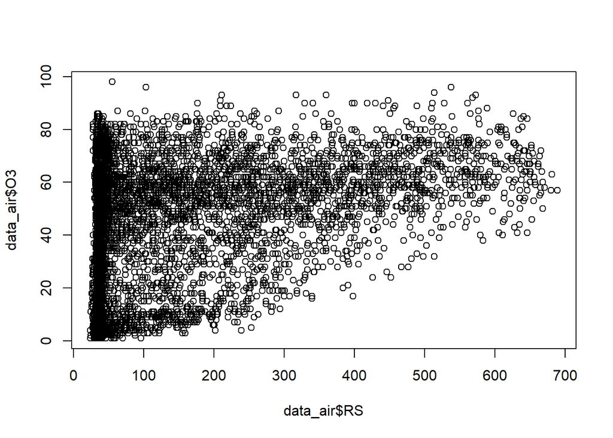

```r
plot(data_air$O3 ~ data_air$RS)
```

Obtenemos ahora el modelo de regresión lineal simple empleando la función de R lm()

```r
modeloRLS <- lm(formula = data_air$O3 ~ data_air$RS)

summary(modeloRLS)
```

```
##
## Call:
## lm(formula = data_air$O3 ~ data_air$RS)
##
## Residuals:
##     Min      1Q  Median      3Q     Max
## -44.494 -19.494   2.075  17.329  60.383
##
## Coefficients:
##              Estimate Std. Error t value Pr(>|t|)
## (Intercept) 34.365621   0.343164  100.14   <2e-16 ***
## data_air$RS  0.059115   0.001721   34.34   <2e-16 ***
## ---
## Signif. codes:  0 '***' 0.001 '**' 0.01 '*' 0.05 '.' 0.1 ' ' 1
##
## Residual standard error: 22.06 on 7400 degrees of freedom
##   (62 observations deleted due to missingness)
## Multiple R-squared:  0.1375, Adjusted R-squared:  0.1374
## F-statistic:  1179 on 1 and 7400 DF,  p-value: < 2.2e-16
```

Interpretamos del modelo resultante que la concentración de ozono en función de la radiación solar es

```
O3 = 34.365621 + 0.059115 * RS
```

Interpretamos la función lo que nos indica que por cada vatio por metro cuadrado de radiación solar la concentración de ozono aumenta en 0.059115 microgramos por metro cúbico.

Mostramos la recta de la regresión sobre el diagrama de dispersión.

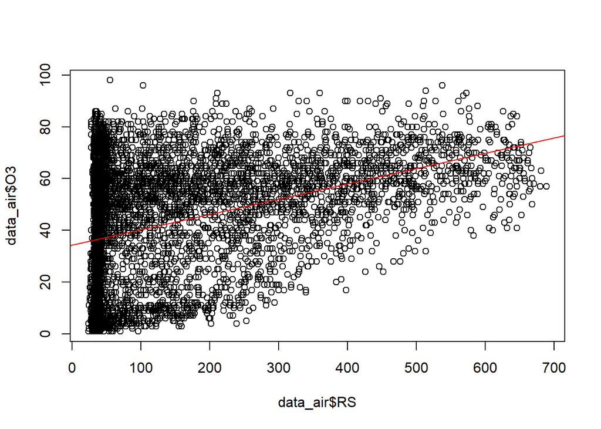

```r
plot(data_air$O3 ~ data_air$RS)
abline(modeloRLS, col = "red")
```

Obtenemos el coeficiente de determinación para calcular la bondad del ajuste. Para eso obtenemos el coeficiente de correlación entre las variables de la concentración de Ozono y la radiación solar.

```r
coef_cor <- cor(data_air$O3, data_air$RS, use="pairwise.complete.obs")
coef_det <- coef_cor ^ 2
c(coef_cor, coef_det)
```

```
## [1] 0.3707692 0.1374698
```

Para la obtención del modelo de regresión lineal de la variable =3 en función de loa variable explicativa de PM10 obtenemos dicha variable explicativa del índice de la calidad del aire en función de la variable PM10.

```r
data_air$PM10_cat <- ""

for (i in 1:length(data_air$PM10)) {
  if (!is.na(data_air$PM10[i])) {
    if(data_air$PM10[i] > 0 & data_air$PM10[i] <= 40){
    data_air$PM10_cat[i] <- "Muy buena"
    } else if (data_air$PM10[i] > 40 & data_air$PM10[i] <= 60) {
        data_air$PM10_cat[i] <- "Buena"
    }else if (data_air$PM10[i] > 60 & data_air$PM10[i] <= 120) {
      data_air$PM10_cat[i] <- "Mejorable"
    }else if (data_air$PM10[i] > 120 & data_air$PM10[i] <= 160) {
      data_air$PM10_cat[i] <- "Mala"
    }else if (data_air$PM10[i] > 160 & data_air$PM10[i] <= 724) {
      data_air$PM10_cat[i] <- "Muy mala"
    }
  }
  else {
    data_air$PM10_cat[i] <- NA
  }

}
```

Obtenemos el modelo de regresión simple de la concentración de ozono en función de la concentración de PM10

```r
modelo2 <- lm(formula=data_air$O3 ~ data_air$PM10_cat,na.action=na.exclude)
summary(modelo2)
```

```
##
## Call:
## lm(formula = data_air$O3 ~ data_air$PM10_cat, na.action = na.exclude)
##
## Residuals:
##     Min      1Q  Median      3Q     Max
## -50.576 -10.576   0.424  11.424  66.107
##
## Coefficients:
##                            Estimate Std. Error t value Pr(>|t|)
## (Intercept)                 29.2320     0.6778   43.13   <2e-16 ***
## data_air$PM10_catMala      -21.7196     1.3237  -16.41   <2e-16 ***
## data_air$PM10_catMejorable -14.3366     0.9140  -15.69   <2e-16 ***
## data_air$PM10_catMuy buena  22.3445     0.7197   31.05   <2e-16 ***
## data_air$PM10_catMuy mala  -22.3393     1.2417  -17.99   <2e-16 ***
## ---
## Signif. codes:  0 '***' 0.001 '**' 0.01 '*' 0.05 '.' 0.1 ' ' 1
##
## Residual standard error: 17.69 on 7387 degrees of freedom
##   (72 observations deleted due to missingness)
## Multiple R-squared:  0.4455, Adjusted R-squared:  0.4452
## F-statistic:  1483 on 4 and 7387 DF,  p-value: < 2.2e-16
```

El modelo resultantes indica que la concentración de ozono sólo aumenta cuando la concentración de PM10 es Muy buena, en el resto de casos la concentración de ozono disminuye. EL modelo resultante en función de la categoría de concentración de PM10 es:

[output not shown]

## 1.3 Modelo de regresión lineal múltiple

Para la obtención del modelo de regresión lineal múltiple nos basamos en el modelo de regresión lineal simple calculado en el apartado anterior para explicar la variable O3 en función de la variable RS. En primer lugar, añadiremos al modelo la variable explicativa de la dirección del viento. Por lo tanto, crearemos un modelo que explique la variable O3 en función de las variables RS y Dir_Aire.

Para obtener el modelo empelamos de nueva la función en R lm().

```r
modeloA <- lm(formula = data_air$O3 ~ data_air$RS + data_air$Dir_Aire, na.action=na.exclude)
summary(modeloA)
```

```
##
## Call:
## lm(formula = data_air$O3 ~ data_air$RS + data_air$Dir_Aire, na.action = na.exclude)
##
## Residuals:
##    Min     1Q Median     3Q    Max
## -51.69 -17.21   1.00  15.53  58.02
##
## Coefficients:
##                    Estimate Std. Error t value Pr(>|t|)
## (Intercept)       51.053991   0.604391   84.47   <2e-16 ***
## data_air$RS        0.043900   0.001676   26.19   <2e-16 ***
## data_air$Dir_Aire -0.080691   0.002476  -32.59   <2e-16 ***
## ---
## Signif. codes:  0 '***' 0.001 '**' 0.01 '*' 0.05 '.' 0.1 ' ' 1
##
## Residual standard error: 20.63 on 7399 degrees of freedom
##   (62 observations deleted due to missingness)
## Multiple R-squared:  0.2457, Adjusted R-squared:  0.2455
## F-statistic:  1205 on 2 and 7399 DF,  p-value: < 2.2e-16
```

Interpretamos del modelo resultante que la concentración de ozono en función de la radiación solar y la dirección del viento es:

```
O3 = 51.053991 + 0.043900 * RS - 0.080691 * Dir_aire
```

Interpretamos la función, lo que nos indica que por cada vatio por metro cuadrado de radiación solar la concentración de ozono aumenta en 0.043900 microgramos por metro cúbico y que por cada grado de la dirección del viento la concentración de ozono disminuye en 0.080691 microgramos por metro cúbico.

Añadiremos ahora al modelo la variable NO2. Calculamos el modelo que explique la variable O3 en función de las variables RS, Dir_Aire y NO2.

```r
modeloB <- lm(formula = data_air$O3 ~ data_air$RS + data_air$Dir_Aire + data_air$NO2, na.action=na.exclude)
summary(modeloB)
```

```
##
## Call:
## lm(formula = data_air$O3 ~ data_air$RS + data_air$Dir_Aire +
##     data_air$NO2, na.action = na.exclude)
##
## Residuals:
##     Min      1Q  Median      3Q     Max
## -51.531 -11.358   0.036  10.821  56.552
##
## Coefficients:
##                    Estimate Std. Error t value Pr(>|t|)
## (Intercept)       67.863089   0.501096  135.43   <2e-16 ***
## data_air$RS        0.034141   0.001257   27.16   <2e-16 ***
## data_air$Dir_Aire -0.063742   0.001860  -34.27   <2e-16 ***
## data_air$NO2      -1.435140   0.018681  -76.82   <2e-16 ***
## ---
## Signif. codes:  0 '***' 0.001 '**' 0.01 '*' 0.05 '.' 0.1 ' ' 1
##
## Residual standard error: 15.39 on 7396 degrees of freedom
##   (64 observations deleted due to missingness)
## Multiple R-squared:  0.5805, Adjusted R-squared:  0.5804
## F-statistic:  3412 on 3 and 7396 DF,  p-value: < 2.2e-16
```

Interpretamos del modelo resultante que la concentración de ozono en función de la radiación solar, la dirección del viento y la concentración de dióxido de nitrógeno es:

```
O3 = 67.863089 + 0.034141 * RS - 0.063742 * Dir_Aire - 1.435140 * NO2
```

Interpretamos la función y lo que indica es que por cada vatio por metro cuadrado de radiación solar la concentración de ozono aumenta en 0.034141 microgramos por metro cúbico, que por cada grado de la dirección del viento la concentración de ozono disminuye en 0.063742 microgramos por metro cúbico y que por cada microgramo por metro cúbico de concentración de dióxido de nitrógeno la concentración de ozono disminuye en 1.435140 microgramos por metro cúbico.

Vemos que este modelo mejora a los anteriores ya que el coeficiente de determinación es de 0.5805 lo que nos indica que el modelo de regresión lineal nos explica el 58,05% de la varianza de las observaciones, lo que mejora el porcentaje de 24,57% obtenido por el modelo anterior.

Obtenemos el factor de inflación de la varianza del modelo anterior añadiéndole la variable Tmp.

```r
modeloC <- lm(formula = data_air$O3 ~ data_air$RS + data_air$Dir_Aire + data_air$NO2 + data_air$Tmp, na.action=na.exclude)
vif(modeloC)
```

```
##       data_air$RS data_air$Dir_Aire      data_air$NO2      data_air$Tmp
##          1.243470          1.119873          1.154998          1.371241
```

Obtenemos el modelo añadiendo la variable Tmp al modelo anterior.

```r
summary(modeloC)
```

```
##
## Call:
## lm(formula = data_air$O3 ~ data_air$RS + data_air$Dir_Aire +
##     data_air$NO2 + data_air$Tmp, na.action = na.exclude)
##
## Residuals:
##    Min     1Q Median     3Q    Max
## -51.49 -11.32   0.13  10.84  56.06
##
## Coefficients:
##                    Estimate Std. Error t value Pr(>|t|)
## (Intercept)       66.444001   0.909846  73.028   <2e-16 ***
## data_air$RS        0.033278   0.001339  24.858   <2e-16 ***
## data_air$Dir_Aire -0.063273   0.001877 -33.712   <2e-16 ***
## data_air$NO2      -1.423202   0.019740 -72.097   <2e-16 ***
## data_air$Tmp       0.088130   0.047166   1.869   0.0617 .
## ---
## Signif. codes:  0 '***' 0.001 '**' 0.01 '*' 0.05 '.' 0.1 ' ' 1
##
## Residual standard error: 15.38 on 7395 degrees of freedom
##   (64 observations deleted due to missingness)
## Multiple R-squared:  0.5807, Adjusted R-squared:  0.5805
## F-statistic:  2561 on 4 and 7395 DF,  p-value: < 2.2e-16
```

Interpretamos del modelo resultante que la concentración de ozono en función de la radiación solar, la dirección del viento, la concentración de dióxido de nitrógeno y la temperatura es:

```
O3 = 66.444001 + 0.033278 * RS - 0.063273 * Dir_Aire - 1.423202 * NO2 + 0.088130 * Tmp
```

Interpretamos la función y lo que indica es que por cada vatio por metro cuadrado de radiación solar la concentración de ozono aumenta en 0.033278 microgramos por metro cúbico, que por cada grado de la dirección del viento la concentración de ozono disminuye en 0.063273 microgramos por metro cúbico, que por cada microgramo por metro cúbico de concentración de dióxido de nitrógeno la concentración de ozono disminuye en 1.423202 microgramos por metro cúbico y que por cada grado centígrado de temperatura la concentración de ozono aumenta en 0.088130 microgramos por metro cúbico.

## 1.4 Diagnosis del modelo

Mostramos el gráfico con los valores ajustados frente a los residuales.

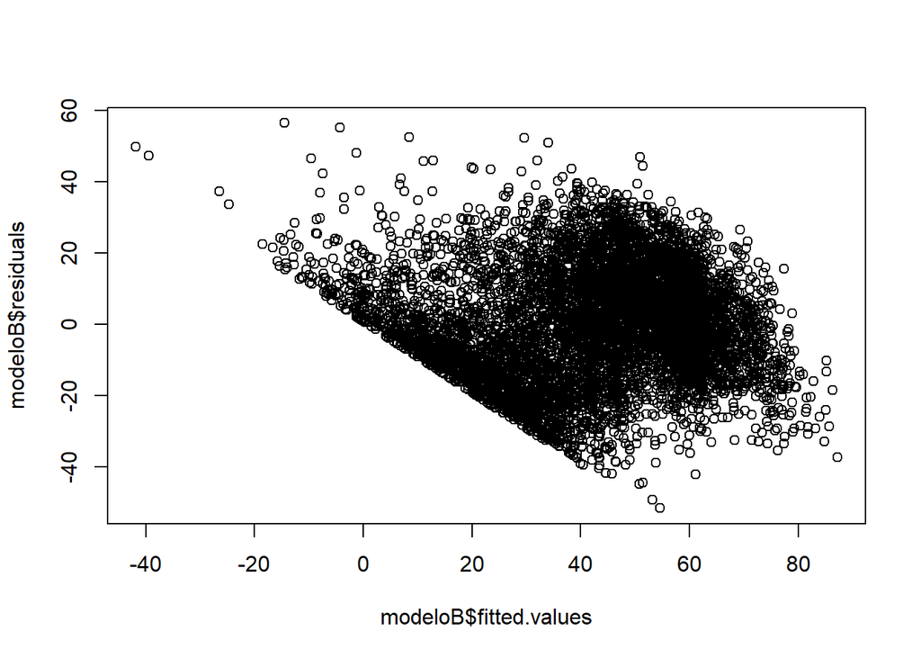

```r
plot(modeloB$fitted.values, modeloB$residuals)
```

Obtenemos el gráfico cuaritl-cuartil en función de los residuos del modelo y la concentración de ozono.

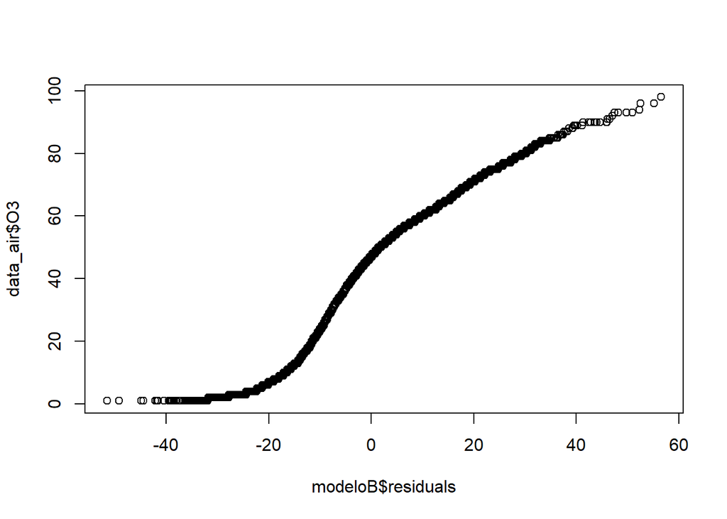

```r
qqplot(modeloB$residuals,data_air$O3)
```

## 1.5 Predicción del modelo

Realizamos el calculo en función de l modelo obtenido anteriormente:

```
O3 = 66.444001 + 0.033278 * RS - 0.063273 * Dir_Aire - 1.423202 * NO2 + 0.088130 * Tmp
```

Aplicamos sobre las variables los valores especificados en el enunciado.

```r
O3 <-  66.444001 + 0.033278 * 160 - 0.063273 * 250 - 1.423202 * 15 + 0.088130 * 20
O3
```

```
## [1] 36.3648
```

Obtenemos que la concentración de ozono sería de 36.3648 microgramos por metro cúbico.

# 2 Regresión logística

Creamos la nueva variable dicotómica icO3.

```r
data_air$icO3 <- -1

for (i in 1:length(data_air$O3)) {
  data_air$icO3[i] <- ifelse(data_air$O3[i] <= 80, 0, 1)
}

head(data_air)
```

```
##   Estacion  latitud  longitud     Fecha Periodo SO2  H2S NO NO2 NOX O3 PM10
## 1       12 43.52096 -5.690707 11/7/2021      24   1 18.3  5  36  43  5   95
## 2       12 43.52096 -5.690707 11/7/2021      23   1  6.2  2  22  24 10   80
## 3       12 43.52096 -5.690707 11/7/2021      22   1  4.3  1  19  20 14   38
## 4       12 43.52096 -5.690707 11/7/2021      21   1  2.7  4  21  26 11   36
## 5       12 43.52096 -5.690707 11/7/2021      20   1  2.1  2  18  20 16   30
## 6       12 43.52096 -5.690707 11/7/2021      19   1  1.3  1  10  10 24   21
##   PM25 BEN TOL MXIL Dir_Aire  Vel  Tmp HR  PRB RS LL  PM10_cat icO3
## 1   30 1.6 2.3  3.2      260 1.49 11.8 93 1025 36  0 Mejorable    0
## 2   23 0.7 1.8  2.7      201 0.98 11.6 93 1025 36  0 Mejorable    0
## 3   15 0.6 1.1  3.1      296 0.98 11.2 92 1025 37  0 Muy buena    0
## 4   12 0.9 1.3  2.2      185 0.99 11.9 88 1026 37  0 Muy buena    0
## 5   12 0.2 0.6  0.8      297 0.99 12.4 85 1026 37  0 Muy buena    0
## 6   17 0.3 0.6  1.0      295 0.99 12.4 83 1026 37  0 Muy buena    0
```

# 3 Conclusiones del análisis

Del estudio realizado obtenemos que el contaminante con mayor relación lineal con la variable meteorológica de la radiación solar es la variable de la concentración de ozono con un coeficiente de correlación positivo de 0.3707692.

Hemos obtenido el modelo de regresión simple que explica la variable de la concentración de ozono en función de la radiación solar, quedando el modelo como:

```
O3 = 34.365621 + 0.059115 * RS
```

Por último hemos que el mejor modelo de regresión múltiple para explicar el nivel de ozono lo obtenemos en función de las variables RS, Dir_Aire, NO2 y TMP con un porcentaje de 58.07%. Quedando el modelo de la siguiente forma:

```
O3 = 66.444001 + 0.033278 * RS - 0.063273 * Dir_Aire - 1.423202 * NO2 + 0.088130 * Tmp
```